# ritalic guide

ritalic is a library designed to provide an easy way to get the data of [ITALIC](https://italic.units.it) from R.”

- The package can be installed from github using the library devtools
- Soon the library will be avalilable in cran too!

```r
# install and load devtools
# install.packages('devtools') # if not already installed
library(devtools)
# install and load ritalic
devtools::install_github("Mattciao96/ritalic")
library(ritalic)
```

Load some other utility libraries

```r
# dplyer for easier data wrangling
library(dplyr)
# leaflet for interactive maps
library(leaflet)
```

# Exploring the library

structure of the library:

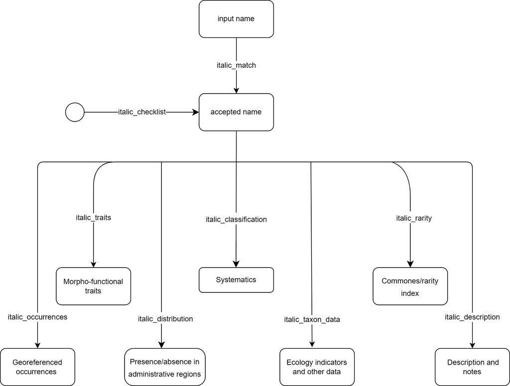

## italic_match

- italic_match is the core function of ritalic:
- takes a list of scientific names as input, aligns them to checklist of ITALIC and retrieves the corresponding accepted names
- accepted names can later be passed to the other functions of the package

```r
match <- ritalic::italic_match(c('Cetraria islandica L. subsp. islandica', 'Lecanora albela','Parmelia caperata (L.) Ach', 'Ramalina americana Hal' ))
```

```r
match
```

| input_name | matched_name | status | accepted_name | name_score | auth_score |
| --- | --- | --- | --- | --- | --- |
| Cetraria islandica L. subsp. islandica | Cetraria islandica (L.) Ach. subsp. islandica | accepted | Cetraria islandica (L.) Ach. subsp. islandica | 100 | 36 |
| Lecanora albela | Lecanora albella (Pers.) Ach. | accepted | Lecanora albella (Pers.) Ach. | 98 | 0 |
| Parmelia caperata (L.) Ach | Parmelia caperata (L.) Ach. | synonym | Flavoparmelia caperata (L.) Hale | 100 | 94 |
| Ramalina americana Hal | NA | NA | NA | 0 | 0 |

```r
accepted_names <- match$accepted_name
```

now we can store the accepted names into a variable to easily pass them to the next functions

```r
accepted_names <- match$accepted_name
```

## italic_description

return the description and the additional notes of a taxon

```r
descriptions <- ritalic::italic_description(accepted_names)
```

```r
descriptions
```

| scientific_name | description | notes |
| --- | --- | --- |
| Cetraria islandica (L.) Ach. subsp. islandica | Thallus subfoliose to subfruticose, loosely attached, often forming large tufts, consisting of dorsiventral, flattened, elongate, ascending, 1-3(- 4) cm broad and up to 6(-10) cm tall, often sparingly… | an arctic-alpine to boreal-montane, circumpolar lichen found on mineral and organic soil, amongst thick moss carpets, exceptionally on bark or lignum near the ground, with optimum near treeline; commo… |
| Lecanora albella (Pers.) Ach. | Thallus crustose, episubstratic, continuous or rimose-areolate in central parts, yellowish white, whitish grey or greenish white, smooth, epruinose. Apothecia lecanorine, sessile, 0.5-1(-1.5) mm acros… | a mainly temperate, perhaps holarctic lichen found on smooth bark, especially of Fagus, but also of Abies in woodlands; apparently more frequent in the past, but perhaps formerly confused with Glaucom… |
| Flavoparmelia caperata (L.) Hale | Thallus foliose, broad-lobed, adnate to loosely adnate, forming regular, 5-20 cm wide rosettes, the individual thalli sometimes coalescing to cover extensive areas. Lobes elongate, flat to slightly co… | a mild-temperate lichen found on isolated deciduous, more rarely evergreen trees, only exceptionally on rocks (e.g. on north-exposed faces of basic siliceous rocks in dry-continental Alpine valleys); … |

## italic_taxon_data

returns data related to the taxon:

**Substrata and morpho-functional traits:**

**substrata**

- saxicolous
- on lignum
- epiphytic
- on soil, terricolous mosses, plant debris
- foliicolous

**photobiont**

- green algae other than Trentepohlia
- trentepohlia
- cyanobacteria, filamentous form, e.g. Nostoc, Scytonema
- cyanobacteria, coccaceous form, e.g. Gloeocapsa, Xanthocapsa

**growth_form**

- fruticose
- fruticose filamentous
- foliose
- foliose broad-lobed, Parmelia type
- foliose narrow-lobed, Physcia type
- foliose umbilicate
- crustose
- crustose endolithic
- crustose placodiomorph
- leprose
- squamulose
- lichenicolous fungus
- non-lichenized, non-lichenicolous fungus

**phytoclimatic_range**

- oceanic
- suboceanic
- subcontinental

**special_requirements_for_water**

- on otherwise dry surfaces with periodical seepage of water after rain
- periodical submerged, e.g. in creeks or on coastal maritime rocks
- on surface seldom wetted by rain, e.g. underhangs

**reproductive_strategy**

- mainly sexual
- mainly asexual, by soredia or soredia-like structures, e.g. blastidia
- mainly asexual, by isidia or isidia-like structures, e.g. schizidia
- mainly asexual, by thallus fragmentation

**Ecological indicators, poleotolerance and altitudinal distribution:**

**ph_of_the_substrata**

- 1 - on very acid substrata, such as lignum and conifer bark
- 2 - on acid substrata, such as on non-eutrophicated bark of Quercus
- 3 - on subacid to subneutral substrata (e.g. on bark of Sambucus)
- 4 - on slightly basic substrata, such as dust-covered bark
- 5 - on basic substrata, e.g. pure limestone

**solar_irradiation**

- 1 - in very shaded situations, e.g. deep gorges, closed evergreen forests
- 2 - in shaded situations, such as on the northern side of boles in close-canopied deciduous forests
- 3 - in sites with plenty of diffuse light but scarce direct solar irradiation, such as in rather open-canopied deciduous woodlands
- 4 - in sun-exposed sites, but avoiding extreme solar irradiation
- 5 - in sites with very high direct solar irradiation, such as on the southern side of isolated boles

**aridity**

- 1 - hydro- and hygrophytic, in aquatic or marine situations, or in sites with a very high frequency of fog
- 2 - rather hygrophytic, intermediate between 1 and 2
- 3 - mesophytic
- 4 - xerophytic, but absent from extremely arid stands
- 5 - very xerophytic

**eutrophication**

- 1 - not resistant to eutrophication
- 2 - resistant to a very weak eutrophication
- 3 - resistant to a weak eutrophication
- 4 - occurring in rather eutrophicated situations
- 5 - occurring in highly eutrophicated situations

**altitudinal_distribution**

- 1 - eu-Mediterranean belt (potential vegetation: evergreen Quercus ilex forest)
- 2 - submediterranean belt (deciduous Quercus-Carpinus forests)
- 3 - montane belt (Fagus forests, marking treeline in the Apennines)
- 4 - subalpine and oroboreal belts of the Alps (natural Picea abies, and Larix-Pinus cembra stands)
- 5 - above treeline (both Alpine and oromediterranean)
- 6 - nival belt of the Alps

**poleotolerance** This value points to the tendency of a lichen to occur in areas with different degrees of human disturbance. It is expressed on 4 classes, as follows:

- 3 - species occurring also in heavily disturbed areas, incl. large towns
- 2 - species occurring also in moderately disturbed areas (agricultural areas, small settlements etc.).
- 1 - species mostly occurring in natural or semi-natural habitats
- 0 - species which exclusively occur on old trees in ancient, undisturbed forests.

```r
taxon_data <-  ritalic::italic_taxon_data(accepted_names)
```

```r
taxon_data
```

| scientific_name | substrata | photobiont | growth_form | phytoclimatic_range | special_requirements_for_water | reproductive_strategy | ph_of_the_substrata_min | ph_of_the_substrata_max | solar_irradiation_min | solar_irradiation_max | aridity_min | aridity_max | eutrophication_min | eutrophication_max | altitudinal_distribution_min | altitudinal_distribution_max | poleotolerance_min | poleotolerance_max |
| --- | --- | --- | --- | --- | --- | --- | --- | --- | --- | --- | --- | --- | --- | --- | --- | --- | --- | --- |
| Cetraria islandica (L.) Ach. subsp. islandica | on soil, terricolous mosses, plant debris | green algae other than Trentepohlia | fruticose | NA | NA | mainly asexual, by thallus fragmentation | 1 | 3 | 3 | 5 | 3 | 4 | 1 | 2 | 3 | 6 | 1 | 1 |
| Lecanora albella (Pers.) Ach. | epiphytic | green algae other than Trentepohlia | crustose | NA | NA | mainly sexual | 1 | 2 | 3 | 3 | 2 | 2 | 1 | 1 | 2 | 3 | 1 | 1 |
| Flavoparmelia caperata (L.) Hale | epiphytic | green algae other than Trentepohlia | foliose broad-lobed, Parmelia type | NA | NA | mainly asexual, by soredia or soredia-like structures, e.g. blastidia | 2 | 3 | 3 | 4 | 3 | 3 | 1 | 3 | 1 | 3 | 1 | 2 |
|  | NA | NA | NA | NA | NA | NA | NA | NA | NA | NA | NA | NA | NA | NA | NA | NA | NA | NA |

## italic_classification

returns the taxonomical classification of a taxon

```r
systematics <- ritalic::italic_classification(accepted_names)
```

```r
systematics
```

| scientific_name | phylum | class | order | family | genus |
| --- | --- | --- | --- | --- | --- |
| Cetraria islandica (L.) Ach. subsp. islandica | Ascomycota | Lecanoromycetes | Lecanorales | Parmeliaceae | Cetraria |
| Lecanora albella (Pers.) Ach. | Ascomycota | Lecanoromycetes | Lecanorales | Lecanoraceae | Lecanora |
| Flavoparmelia caperata (L.) Hale | Ascomycota | Lecanoromycetes | Lecanorales | Parmeliaceae | Flavoparmelia |
|  | NA | NA | NA | NA | NA |

## italic_rarity

returns the commonness-rarity for each ecoregion of Italy

**How to read and understand the values:**

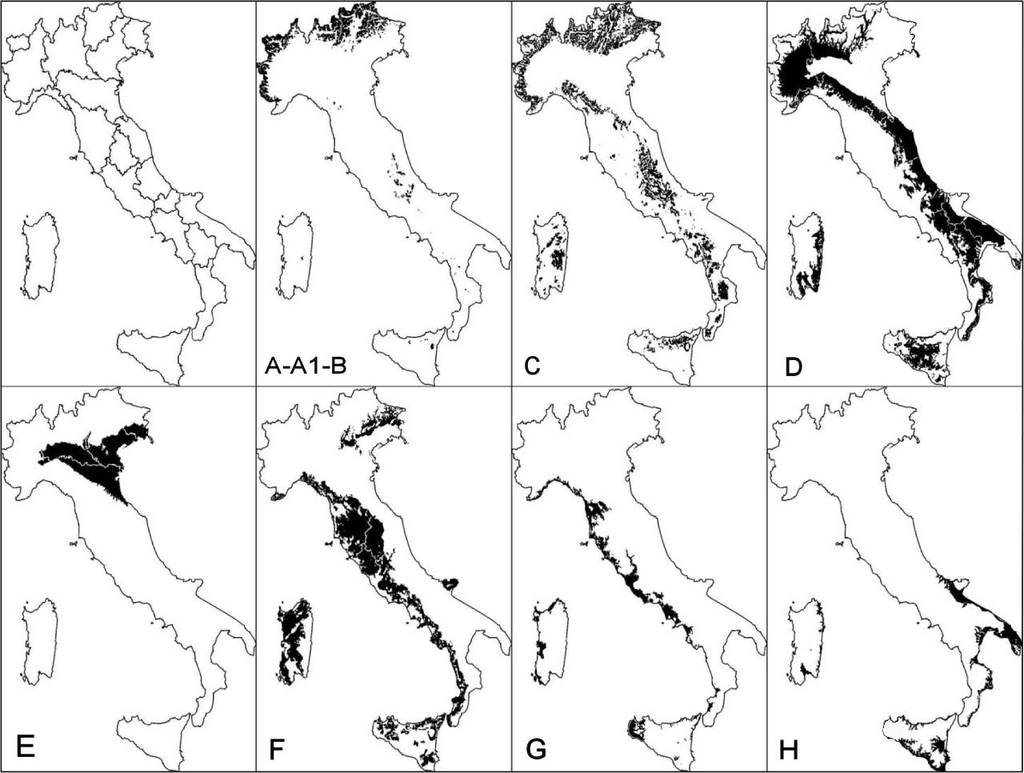

ecoregions in Italy

## Ecoregions in italy A: Alpine (above treeline in the Alps and in Abruzzo) A1: Subalpine (near treeline in the Alps, oroboreal belt) B: Oromediterranean (above treeline outside the Alps except Abruzzo) C: Montane (beech forests) D: Dry submediterranean (deciduous oaks, excluding SmedH) E: Padanian (the plains of the North): this is the only OGU which was not separated on the basis of climatical-biogeographical characters; it is the most heavily anthropised part of Italy, where several species do not occur because of pollution and/or almost total deforestation F: Humid submediterranean (as SmedD, but restricted to areas with a warm-humid climate, mostly Tyrrhenian) G: Humid Mediterranean (mostly Tyrrhenian) H: Dry Mediterranean

```r
rarity <- ritalic::italic_rarity(accepted_names)
```

```r
rarity
```

| scientific_name | alpine | subalpine | oromediterranean | montane | dry_submediterranean | padanian | humid_submediterranean | humid_mediterranean | dry_mediterranean |
| --- | --- | --- | --- | --- | --- | --- | --- | --- | --- |
| Cetraria islandica (L.) Ach. subsp. islandica | very common | extremely common | rare | very rare | absent | absent | absent | absent | absent |
| Lecanora albella (Pers.) Ach. | absent | absent | absent | rather rare | very rare | absent | very rare | absent | absent |
| Flavoparmelia caperata (L.) Hale | absent | absent | absent | very rare | common | extremely rare | very common | rather rare | extremely rare |
|  | NA | NA | NA | NA | NA | NA | NA | NA | NA |

## italic_distribution

returns the presence / absence (1 / 0) of a taxon in each of the 20 administrative regions of Italy

**Administrative regions:**

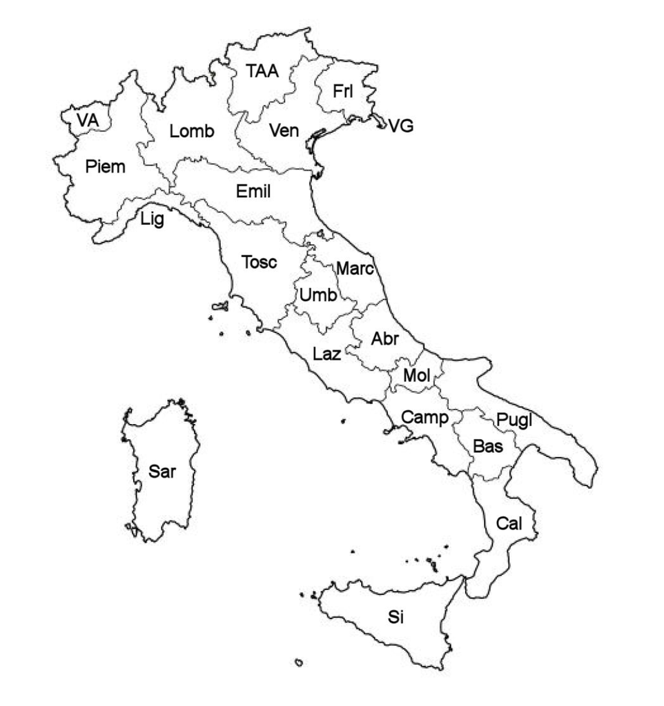

```r
distribution <- ritalic::italic_distribution(accepted_names)
```

```r
distribution
```

| scientific_name | abruzzo | basilicata | calabria | campania | emilia_romagna | friuli_venezia_giulia | lazio | liguria | lombardia | marche | molise | piemonte | puglia | sardegna | sicilia | toscana | trentino_alto_adige | umbria | valle_d_aosta | veneto |
| --- | --- | --- | --- | --- | --- | --- | --- | --- | --- | --- | --- | --- | --- | --- | --- | --- | --- | --- | --- | --- |
| Cetraria islandica (L.) Ach. subsp. islandica | 1 | 1 | 1 | 1 | 1 | 1 | 1 | 1 | 1 | 1 | 1 | 1 | 0 | 0 | 0 | 1 | 1 | 1 | 1 | 1 |
| Lecanora albella (Pers.) Ach. | 0 | 1 | 1 | 1 | 1 | 1 | 1 | 1 | 1 | 1 | 1 | 1 | 1 | 1 | 1 | 1 | 1 | 1 | 1 | 1 |
| Flavoparmelia caperata (L.) Hale | 1 | 1 | 1 | 1 | 1 | 1 | 1 | 1 | 1 | 1 | 1 | 1 | 1 | 1 | 1 | 1 | 1 | 1 | 1 | 1 |
|  | NA | NA | NA | NA | NA | NA | NA | NA | NA | NA | NA | NA | NA | NA | NA | NA | NA | NA | NA | NA |

## italic_occurrences

returns all the georeferenced occurrences of a taxon

```r
occurrences <- ritalic::italic_occurrences(accepted_names[1])
```

```r
occurrences <- occurrences %>%
  mutate(decimalLatitude = as.numeric(decimalLatitude)) %>%
  mutate(decimalLongitude = as.numeric(decimalLongitude)) %>%
  mutate(coordinatesUncertaintyInMeters = as.numeric(coordinatesUncertaintyInMeters))
nrow(occurrences)
```

```
## [1] 358
```

```r
head(occurrences)
```

|  | scientificName | decimalLatitude | decimalLongitude | coordinatesUncertaintyInMeters | habitat | institutionCode | eventDate |
| --- | --- | --- | --- | --- | --- | --- | --- |
| 1 | Cetraria islandica (L.) Ach. subsp. islandica | 45.8699 | 11.2740 | 3000 | Soil and plant debris | herbarium TSB | 1988 |
| 2 | Cetraria islandica (L.) Ach. subsp. islandica | 46.5548 | 12.9737 | 100 | Soil and plant debris | herbarium TSB | 1988 |
| 3 | Cetraria islandica (L.) Ach. subsp. islandica | 46.5611 | 11.9534 | 2000 | Wood of conifers | herbarium TSB | 1988 |
| 4 | Cetraria islandica (L.) Ach. subsp. islandica | 38.1624 | 15.9227 | 1000 | Soil over siliceous substrata | herbarium TSB | 1988 |
| 5 | Cetraria islandica (L.) Ach. subsp. islandica | 46.4115 | 13.4374 | 100 | Soil and plant debris | herbarium TSB | 1989 |
| 6 | Cetraria islandica (L.) Ach. subsp. islandica | 46.5218 | 12.6737 | 500 | Soil over calcareous substrata | herbarium TSB | 1989 |

The occurrences can be displayed in a nice map with leaflet:

```r
occurrences %>%
  leaflet() %>%
  addTiles() %>%
  setView(lng = 9.0, lat = 42.0, zoom = 5) %>%
  #addMarkers(~decimalLongitude, ~decimalLatitude, popup = ~scientificName)
  addCircleMarkers(~decimalLongitude, ~decimalLatitude,
    radius = 3,
    color = "red",
    stroke = FALSE, fillOpacity = 1
  )
```

[interactive chart not shown]

## italic_checklist

```r
checklist <- ritalic::italic_checklist()
head(checklist)
```

```
## [1] "Absconditella annexa (Arnold) Vězda"
## [2] "Absconditella lignicola Vězda & Pišút"
## [3] "Acarospora admissa (Nyl.) Kullh."
## [4] "Acarospora atrata Hue"
## [5] "Acarospora badiofusca (Nyl.) Th. Fr."
## [6] "Acarospora bullata Anzi"
```

## italic_traits

!!! function in development retuns a the traits assigned based on the identification keys in ITALIC

```r
traits <- ritalic::italic_traits(accepted_names)
```

```r
traits
```

| scientific_name | growth_form_fruticose | growth_form_foliose | growth_form_squamulose | growth_form_leprose | growth_form_crustose | growth_form_lichenicolous | photobiont_cyanobacterial | photobiont_trentepohlioid | photobiont_chlorococcoid | photobiont_absent | ascocarps_present | ascocarps_perithecioid | ascocarps_apothecioid | apothecia_lecanorine | apothecia_lirelliform | ascospores_pigmented | ascospores_hyaline | ascospores_1_celled | ascospores_2_celled | ascospores_more_than_2_celled | ascospores_polarilocular | ascospores_muriform_or_submuriform | ascospores_less_than_8_per_ascus | ascospores_8_per_ascus | ascospores_more_than_8_per_ascus | on_bark_and_wood | on_soil__terricolous_mosses_and_plant_debris | on_rock | on_calcareous_substrata | … |
| --- | --- | --- | --- | --- | --- | --- | --- | --- | --- | --- | --- | --- | --- | --- | --- | --- | --- | --- | --- | --- | --- | --- | --- | --- | --- | --- | --- | --- | --- | --- |
| Cetraria islandica (L.) Ach. subsp. islandica | 1 | 0 | 0 | 0 | 0 | 0 | 0 | 0 | 1 | 0 | 1 | 0 | 1 | 1 | 0 | 0 | 1 | 1 | 0 | 0 | 0 | 0 | 1 | 0 | 0 | 0 | 1 | 0 | 0 | … |
| Lecanora albella (Pers.) Ach. | 0 | 0 | 0 | 0 | 1 | 0 | 0 | 0 | 1 | 0 | 1 | 0 | 1 | 1 | 0 | 0 | 1 | 1 | 0 | 0 | 0 | 0 | 1 | 0 | 0 | 1 | 0 | 0 | 0 | … |
| Flavoparmelia caperata (L.) Hale | 0 | 1 | 0 | 0 | 0 | 0 | 0 | 0 | 1 | 0 | 1 | 0 | 1 | 1 | 0 | 0 | 1 | 1 | 0 | 0 | 0 | 0 | 1 | 0 | 0 | 1 | 0 | 0 | 0 | … |
|  | NA | NA | NA | NA | NA | NA | NA | NA | NA | NA | NA | NA | NA | NA | NA | NA | NA | NA | NA | NA | NA | NA | NA | NA | NA | NA | NA | NA | NA | … |